# Mouse Muscle Stem Cell Project

Dirichlet Regression

Rick Farouni

Génome Québec Innovation Centre, McGill University, Montreal, Canada

2021-November-08

In this analysis we try to infer the effect of aging on the cell type composition in mouse tissue samples.

## Paper reference

[Link to Reference on Dirichlet Regression](https://epub.wu.ac.at/4077/1/Report125.pdf)

## Load libraries

```r
library (DirichletReg)
library(tidyverse)
```

## Load data

```r
facs_dt <- read_tsv("cells_type_facs_proportions.txt")
facs_dt <-
  facs_dt  %>%
  relocate(fap, .before =musc ) %>%
  mutate(condition=if_else(condition=="yng", 0, 1))
facs_dt
```

| fap | musc | macrophage | condition |
| --- | --- | --- | --- |
| 0.252 | 0.617 | 0.1300 | 0 |
| 0.180 | 0.713 | 0.1065 | 0 |
| 0.328 | 0.476 | 0.1955 | 0 |
| 0.171 | 0.625 | 0.2033 | 0 |
| 0.473 | 0.374 | 0.1521 | 1 |
| 0.634 | 0.316 | 0.0500 | 1 |
| 0.424 | 0.501 | 0.0750 | 1 |
| 0.608 | 0.373 | 0.0177 | 1 |

```r
inputData <- facs_dt
inputData$Y <- DR_data(facs_dt[,1:3])
```

```
not all rows sum up to 1 => normalization forced
```

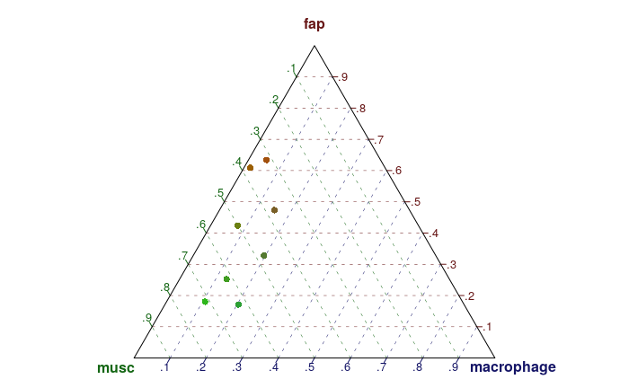

```r
plot(inputData$Y)
```

# Fit models

## Three covariate model

### Model 1: The age covariate of the three components does not differ. That is, it affects all components.

```r
fit1 <- DirichReg(Y ~ condition, inputData)
```

```r
summary(fit1)
```

```
Call:
DirichReg(formula = Y ~ condition, data = inputData)

Standardized Residuals:
                Min       1Q   Median      3Q     Max
fap         -1.2876  -0.9208  -0.1898  0.9336  1.6134
musc        -1.8891  -0.4261  -0.0371  0.5281  1.5665
macrophage  -1.1906  -0.7241  -0.1744  0.6942  1.8624

------------------------------------------------------------------
Beta-Coefficients for variable no. 1: fap
            Estimate Std. Error z value Pr(>|z|)
(Intercept)   2.4473     0.5044   4.852 1.23e-06 ***
condition     0.4116     0.7193   0.572    0.567
------------------------------------------------------------------
Beta-Coefficients for variable no. 2: musc
            Estimate Std. Error z value Pr(>|z|)
(Intercept)   3.4052     0.5048   6.746 1.52e-11 ***
condition    -0.8491     0.7194  -1.180    0.238
------------------------------------------------------------------
Beta-Coefficients for variable no. 3: macrophage
            Estimate Std. Error z value Pr(>|z|)
(Intercept)   2.0841     0.5041   4.134 3.56e-05 ***
condition    -1.2559     0.7146  -1.758   0.0788 .
------------------------------------------------------------------
Significance codes: 0 ‘***’ 0.001 ‘**’ 0.01 ‘*’ 0.05 ‘.’ 0.1 ‘ ’ 1

Log-likelihood: 23.74 on 6 df (55 BFGS + 1 NR Iterations)
AIC: -35.48, BIC: -35.01
Number of Observations: 8
Link: Log
Parametrization: common
```

```r
predict(fit1)
```

```
           fap      musc macrophage
[1,] 0.2324647 0.6058644  0.1616709
[2,] 0.2324647 0.6058644  0.1616709
[3,] 0.2324647 0.6058644  0.1616709
[4,] 0.2324647 0.6058644  0.1616709
[5,] 0.5347745 0.3950431  0.0701824
[6,] 0.5347745 0.3950431  0.0701824
[7,] 0.5347745 0.3950431  0.0701824
[8,] 0.5347745 0.3950431  0.0701824
```

## One covariate models

### Model 2: The age covariate affects MuSC only

```r
fit2 <- DirichReg(Y ~ 1 |condition|1, inputData)
```

```r
summary(fit2)
```

```
Call:
DirichReg(formula = Y ~ 1 | condition | 1, data = inputData)

Standardized Residuals:
                Min       1Q   Median      3Q     Max
fap         -1.2748  -0.6187   0.0075  0.5830  1.4535
musc        -1.3099  -0.3789  -0.0975  0.2902  0.9938
macrophage  -1.4040  -0.8419   0.1303  0.8273  1.7462

------------------------------------------------------------------
Beta-Coefficients for variable no. 1: fap
            Estimate Std. Error z value Pr(>|z|)
(Intercept)   1.8398     0.3644   5.049 4.44e-07 ***
------------------------------------------------------------------
Beta-Coefficients for variable no. 2: musc
            Estimate Std. Error z value Pr(>|z|)
(Intercept)   2.5724     0.3957   6.500 8.02e-11 ***
condition    -0.8279     0.3340  -2.479   0.0132 *
------------------------------------------------------------------
Beta-Coefficients for variable no. 3: macrophage
            Estimate Std. Error z value Pr(>|z|)
(Intercept)   0.7135     0.3596   1.984   0.0473 *
------------------------------------------------------------------
Significance codes: 0 ‘***’ 0.001 ‘**’ 0.01 ‘*’ 0.05 ‘.’ 0.1 ‘ ’ 1

Log-likelihood: 17.16 on 4 df (42 BFGS + 1 NR Iterations)
AIC: -26.32, BIC: -26
Number of Observations: 8
Link: Log
Parametrization: common
```

```r
predict(fit2)
```

```
           fap      musc macrophage
[1,] 0.2937053 0.6110673 0.09522741
[2,] 0.2937053 0.6110673 0.09522741
[3,] 0.2937053 0.6110673 0.09522741
[4,] 0.2937053 0.6110673 0.09522741
[5,] 0.4477481 0.4070796 0.14517235
[6,] 0.4477481 0.4070796 0.14517235
[7,] 0.4477481 0.4070796 0.14517235
[8,] 0.4477481 0.4070796 0.14517235
```

### Model 3: The age covariate affects macrophage only

```r
fit3 <- DirichReg(Y ~ 1 |1 |condition, inputData)
```

```r
summary(fit3)
```

```
Call:
DirichReg(formula = Y ~ 1 | 1 | condition, data = inputData)

Standardized Residuals:
                Min       1Q   Median      3Q     Max
fap         -1.4979  -0.9611   0.0679  0.9565  1.9593
musc        -1.6255  -1.1770  -0.0867  1.1874  1.9482
macrophage  -0.9468  -0.5843  -0.3345  0.1894  0.8924

------------------------------------------------------------------
Beta-Coefficients for variable no. 1: fap
            Estimate Std. Error z value Pr(>|z|)
(Intercept)   1.6769     0.3665   4.575 4.76e-06 ***
------------------------------------------------------------------
Beta-Coefficients for variable no. 2: musc
            Estimate Std. Error z value Pr(>|z|)
(Intercept)   1.9866     0.3674   5.407 6.39e-08 ***
------------------------------------------------------------------
Beta-Coefficients for variable no. 3: macrophage
            Estimate Std. Error z value Pr(>|z|)
(Intercept)   1.0178     0.4198   2.425   0.0153 *
condition    -0.8322     0.4878  -1.706   0.0880 .
------------------------------------------------------------------
Significance codes: 0 ‘***’ 0.001 ‘**’ 0.01 ‘*’ 0.05 ‘.’ 0.1 ‘ ’ 1

Log-likelihood: 15.89 on 4 df (40 BFGS + 1 NR Iterations)
AIC: -23.79, BIC: -23.47
Number of Observations: 8
Link: Log
Parametrization: common
```

```r
predict(fit3)
```

```
           fap      musc macrophage
[1,] 0.3471766 0.4732138 0.17960966
[2,] 0.3471766 0.4732138 0.17960966
[3,] 0.3471766 0.4732138 0.17960966
[4,] 0.3471766 0.4732138 0.17960966
[5,] 0.3863808 0.5266505 0.08696866
[6,] 0.3863808 0.5266505 0.08696866
[7,] 0.3863808 0.5266505 0.08696866
[8,] 0.3863808 0.5266505 0.08696866
```

### Model 4: The age covariate affects fap only

```r
fit4 <- DirichReg(Y ~ condition |1 |1, inputData)
```

```r
summary(fit4)
```

```
Call:
DirichReg(formula = Y ~ condition | 1 | 1, data = inputData)

Standardized Residuals:
                Min       1Q   Median      3Q     Max
fap         -1.4325  -0.7952  -0.2831  1.0118  1.3223
musc        -1.5837  -0.3279  -0.0993  0.2424  1.5819
macrophage  -1.5535  -0.5274  -0.1409  0.9322  1.6319

------------------------------------------------------------------
Beta-Coefficients for variable no. 1: fap
            Estimate Std. Error z value Pr(>|z|)
(Intercept)   1.8168     0.3915   4.640 3.48e-06 ***
condition     1.2881     0.2681   4.804 1.55e-06 ***
------------------------------------------------------------------
Beta-Coefficients for variable no. 2: musc
            Estimate Std. Error z value Pr(>|z|)
(Intercept)   2.7752     0.3602   7.705 1.31e-14 ***
------------------------------------------------------------------
Beta-Coefficients for variable no. 3: macrophage
            Estimate Std. Error z value Pr(>|z|)
(Intercept)    1.249      0.358   3.488 0.000487 ***
------------------------------------------------------------------
Significance codes: 0 ‘***’ 0.001 ‘**’ 0.01 ‘*’ 0.05 ‘.’ 0.1 ‘ ’ 1

Log-likelihood: 22.09 on 4 df (35 BFGS + 2 NR Iterations)
AIC: -36.18, BIC: -35.86
Number of Observations: 8
Link: Log
Parametrization: common
```

```r
predict(fit4)
```

```
           fap      musc macrophage
[1,] 0.2395629 0.6246963 0.13574079
[2,] 0.2395629 0.6246963 0.13574079
[3,] 0.2395629 0.6246963 0.13574079
[4,] 0.2395629 0.6246963 0.13574079
[5,] 0.5332003 0.3834743 0.08332545
[6,] 0.5332003 0.3834743 0.08332545
[7,] 0.5332003 0.3834743 0.08332545
[8,] 0.5332003 0.3834743 0.08332545
```

*Fit 4 is the best fitting one covariate model*

## Two covariate models

### Model 5: The age covariate affects both musc and macrophage only

```r
fit5 <- DirichReg(Y ~ 1 |condition |condition, inputData)
```

```r
summary(fit5)
```

```
Call:
DirichReg(formula = Y ~ 1 | condition | condition, data = inputData)

Standardized Residuals:
                Min       1Q   Median      3Q     Max
fap         -1.1579  -1.0202  -0.1285  0.8958  1.7152
musc        -2.0454  -0.4069  -0.0242  0.5163  1.7144
macrophage  -1.1364  -0.7569  -0.2176  0.7858  1.5758

------------------------------------------------------------------
Beta-Coefficients for variable no. 1: fap
            Estimate Std. Error z value Pr(>|z|)
(Intercept)   2.6280     0.3603   7.293 3.03e-13 ***
------------------------------------------------------------------
Beta-Coefficients for variable no. 2: musc
            Estimate Std. Error z value Pr(>|z|)
(Intercept)   3.5766     0.3763   9.504  < 2e-16 ***
condition    -1.2354     0.2505  -4.931 8.17e-07 ***
------------------------------------------------------------------
Beta-Coefficients for variable no. 3: macrophage
            Estimate Std. Error z value Pr(>|z|)
(Intercept)   2.2483     0.3868   5.813 6.14e-09 ***
condition    -1.5961     0.3934  -4.057 4.96e-05 ***
------------------------------------------------------------------
Significance codes: 0 ‘***’ 0.001 ‘**’ 0.01 ‘*’ 0.05 ‘.’ 0.1 ‘ ’ 1

Log-likelihood: 23.58 on 5 df (55 BFGS + 1 NR Iterations)
AIC: -37.16, BIC: -36.76
Number of Observations: 8
Link: Log
Parametrization: common
```

```r
predict(fit5)
```

```
           fap      musc macrophage
[1,] 0.2344105 0.6052355 0.16035392
[2,] 0.2344105 0.6052355 0.16035392
[3,] 0.2344105 0.6052355 0.16035392
[4,] 0.2344105 0.6052355 0.16035392
[5,] 0.5292959 0.3973182 0.07338587
[6,] 0.5292959 0.3973182 0.07338587
[7,] 0.5292959 0.3973182 0.07338587
[8,] 0.5292959 0.3973182 0.07338587
```

### Model 6: The age covariate affects both macrophage and fap only

```r
fit6 <- DirichReg(Y ~  condition | 1 | condition, inputData)
```

```r
summary(fit6)
```

```
Call:
DirichReg(formula = Y ~ condition | 1 | condition, data = inputData)

Standardized Residuals:
                Min       1Q   Median      3Q     Max
fap         -1.4821  -0.8244  -0.2783  1.0759  1.3790
musc        -1.3654  -0.5774  -0.0586  0.5894  1.3907
macrophage  -1.3303  -0.6411  -0.1085  0.4608  2.3400

------------------------------------------------------------------
Beta-Coefficients for variable no. 1: fap
            Estimate Std. Error z value Pr(>|z|)
(Intercept)   1.9761     0.3883   5.089  3.6e-07 ***
condition     1.2054     0.2595   4.645  3.4e-06 ***
------------------------------------------------------------------
Beta-Coefficients for variable no. 2: musc
            Estimate Std. Error z value Pr(>|z|)
(Intercept)   2.8967     0.3596   8.056  7.9e-16 ***
------------------------------------------------------------------
Beta-Coefficients for variable no. 3: macrophage
            Estimate Std. Error z value Pr(>|z|)
(Intercept)   1.6242     0.3952   4.110 3.96e-05 ***
condition    -0.5239     0.3686  -1.421    0.155
------------------------------------------------------------------
Significance codes: 0 ‘***’ 0.001 ‘**’ 0.01 ‘*’ 0.05 ‘.’ 0.1 ‘ ’ 1

Log-likelihood: 23.06 on 5 df (45 BFGS + 1 NR Iterations)
AIC: -36.13, BIC: -35.73
Number of Observations: 8
Link: Log
Parametrization: common
```

```r
predict(fit6)
```

```
           fap      musc macrophage
[1,] 0.2372955 0.5958070 0.16689744
[2,] 0.2372955 0.5958070 0.16689744
[3,] 0.2372955 0.5958070 0.16689744
[4,] 0.2372955 0.5958070 0.16689744
[5,] 0.5327840 0.4007381 0.06647788
[6,] 0.5327840 0.4007381 0.06647788
[7,] 0.5327840 0.4007381 0.06647788
[8,] 0.5327840 0.4007381 0.06647788
```

### Model 7: The age covariate affects both fap and musc only

```r
fit7 <- DirichReg(Y ~  condition | condition | 1, inputData)
```

```r
summary(fit7)
```

```
Call:
DirichReg(formula = Y ~ condition | condition | 1, data = inputData)

Standardized Residuals:
                Min       1Q   Median      3Q     Max
fap         -1.5125  -0.8145  -0.2857  1.0313  1.4135
musc        -1.3694  -0.4706  -0.0886  0.3813  1.5497
macrophage  -1.5166  -0.6144  -0.1373  0.6769  2.0274

------------------------------------------------------------------
Beta-Coefficients for variable no. 1: fap
            Estimate Std. Error z value Pr(>|z|)
(Intercept)   1.7486     0.4184   4.179 2.92e-05 ***
condition     1.4783     0.4012   3.684 0.000229 ***
------------------------------------------------------------------
Beta-Coefficients for variable no. 2: musc
            Estimate Std. Error z value Pr(>|z|)
(Intercept)   2.6789     0.4088   6.554 5.61e-11 ***
condition     0.2420     0.3818   0.634    0.526
------------------------------------------------------------------
Beta-Coefficients for variable no. 3: macrophage
            Estimate Std. Error z value Pr(>|z|)
(Intercept)    1.271      0.358   3.549 0.000387 ***
------------------------------------------------------------------
Significance codes: 0 ‘***’ 0.001 ‘**’ 0.01 ‘*’ 0.05 ‘.’ 0.1 ‘ ’ 1

Log-likelihood: 22.29 on 5 df (54 BFGS + 1 NR Iterations)
AIC: -34.58, BIC: -34.18
Number of Observations: 8
Link: Log
Parametrization: common
```

```r
predict(fit7)
```

```
           fap      musc macrophage
[1,] 0.2406582 0.6101354 0.14920646
[2,] 0.2406582 0.6101354 0.14920646
[3,] 0.2406582 0.6101354 0.14920646
[4,] 0.2406582 0.6101354 0.14920646
[5,] 0.5325522 0.3921624 0.07528543
[6,] 0.5325522 0.3921624 0.07528543
[7,] 0.5325522 0.3921624 0.07528543
[8,] 0.5325522 0.3921624 0.07528543
```

*Fit 5 is the best fitting two covariates model*

### Model 8: Mean-Precision parmaterization

```r
fit8 <- DirichReg(Y ~ condition | condition, inputData, model="alternative")
```

```r
summary(fit8)
```

```
Call:
DirichReg(formula = Y ~ condition | condition, data = inputData, model = "alternative")

Standardized Residuals:
                Min       1Q   Median      3Q     Max
fap         -1.2876  -0.9208  -0.1898  0.9336  1.6134
musc        -1.8891  -0.4261  -0.0371  0.5281  1.5665
macrophage  -1.1906  -0.7241  -0.1744  0.6942  1.8624

MEAN MODELS:
------------------------------------------------------------------
Coefficients for variable no. 1: fap
- variable omitted (reference category) -
------------------------------------------------------------------
Coefficients for variable no. 2: musc
            Estimate Std. Error z value Pr(>|z|)
(Intercept)   0.9579     0.1704   5.620 1.90e-08 ***
condition    -1.2608     0.2483  -5.077 3.83e-07 ***
------------------------------------------------------------------
Coefficients for variable no. 3: macrophage
            Estimate Std. Error z value Pr(>|z|)
(Intercept)  -0.3632     0.2236  -1.624    0.104
condition    -1.6676     0.3989  -4.181  2.9e-05 ***
------------------------------------------------------------------

PRECISION MODEL:
------------------------------------------------------------------
            Estimate Std. Error z value Pr(>|z|)
(Intercept)   3.9063     0.4949   7.893 2.96e-15 ***
condition    -0.4215     0.7023  -0.600    0.548
------------------------------------------------------------------
Significance codes: 0 ‘***’ 0.001 ‘**’ 0.01 ‘*’ 0.05 ‘.’ 0.1 ‘ ’ 1

Log-likelihood: 23.74 on 6 df (29 BFGS + 1 NR Iterations)
AIC: -35.48, BIC: -35.01
Number of Observations: 8
Links: Logit (Means) and Log (Precision)
Parametrization: alternative
```

```r
predict(fit8)
```

```
           fap      musc macrophage
[1,] 0.2324647 0.6058644  0.1616709
[2,] 0.2324647 0.6058644  0.1616709
[3,] 0.2324647 0.6058644  0.1616709
[4,] 0.2324647 0.6058644  0.1616709
[5,] 0.5347745 0.3950431  0.0701824
[6,] 0.5347745 0.3950431  0.0701824
[7,] 0.5347745 0.3950431  0.0701824
[8,] 0.5347745 0.3950431  0.0701824
```

### Model 9: Mean-Precision parmaterization. Condition affects mean only

```r
fit9 <- DirichReg(Y ~ condition | 1, inputData, model="alternative")
```

```r
summary(fit9)
```

```
Call:
DirichReg(formula = Y ~ condition | 1, data = inputData, model = "alternative")

Standardized Residuals:
                Min       1Q   Median      3Q     Max
fap         -1.4328  -0.8354  -0.2571  1.0046  1.4273
musc        -1.6579  -0.4731  -0.0472  0.5549  1.4257
macrophage  -1.2734  -0.6677  -0.1435  0.5949  2.1209

MEAN MODELS:
------------------------------------------------------------------
Coefficients for variable no. 1: fap
- variable omitted (reference category) -
------------------------------------------------------------------
Coefficients for variable no. 2: musc
            Estimate Std. Error z value Pr(>|z|)
(Intercept)   0.9509     0.1901   5.003 5.63e-07 ***
condition    -1.2556     0.2515  -4.992 5.96e-07 ***
------------------------------------------------------------------
Coefficients for variable no. 3: macrophage
            Estimate Std. Error z value Pr(>|z|)
(Intercept)  -0.3583     0.2484  -1.443    0.149
condition    -1.7041     0.3899  -4.370 1.24e-05 ***
------------------------------------------------------------------

PRECISION MODEL:
------------------------------------------------------------------
            Estimate Std. Error z value Pr(>|z|)
(Intercept)   3.6752     0.3508   10.48   <2e-16 ***
------------------------------------------------------------------
Significance codes: 0 ‘***’ 0.001 ‘**’ 0.01 ‘*’ 0.05 ‘.’ 0.1 ‘ ’ 1

Log-likelihood: 23.56 on 5 df (37 BFGS + 1 NR Iterations)
AIC: -37.13, BIC: -36.73
Number of Observations: 8
Links: Logit (Means) and Log (Precision)
Parametrization: alternative
```

```r
predict(fit9)
```

```
           fap      musc macrophage
[1,] 0.2332642 0.6037236 0.16301216
[2,] 0.2332642 0.6037236 0.16301216
[3,] 0.2332642 0.6037236 0.16301216
[4,] 0.2332642 0.6037236 0.16301216
[5,] 0.5363304 0.3954813 0.06818828
[6,] 0.5363304 0.3954813 0.06818828
[7,] 0.5363304 0.3954813 0.06818828
[8,] 0.5363304 0.3954813 0.06818828
```

## Determine best fitting model

### Determine whether the full model is a better fit than the best fitting one covariate model (fit4)

```r
anova(fit4, fit1)
```

```
Analysis of Deviance Table

Model 1: DirichReg(formula = Y ~ condition | 1 | 1, data = inputData)
Model 2: DirichReg(formula = Y ~ condition, data = inputData)

        Deviance N. par Difference df Pr(>Chi)
Model 1  -44.183      4
Model 2  -47.483      6     3.3006  2    0.192
```

Model 1 is more parsimonous. Fit4 is better

### Determine whether the best fitting two covariate model (fit5) is a better than the best fitting one covariate model (fit4)

```r
anova(fit4, fit5)
```

```
Analysis of Deviance Table

Model 1: DirichReg(formula = Y ~ condition | 1 | 1, data = inputData)
Model 2: DirichReg(formula = Y ~ 1 | condition | condition, data = inputData)

        Deviance N. par Difference df Pr(>Chi)
Model 1  -44.183      4
Model 2  -47.159      5     2.9767  1  0.08447 .
---
Signif. codes:  0 ‘***’ 0.001 ‘**’ 0.01 ‘*’ 0.05 ‘.’ 0.1 ‘ ’ 1
```

Model 2 is slightly better

### Determine whether mean or mean-percision model is a better fit

```r
anova(fit8, fit9)
```

```
Analysis of Deviance Table

Model 1: DirichReg(formula = Y ~ condition | condition, data = inputData, model = "alternative")
Model 2: DirichReg(formula = Y ~ condition | 1, data = inputData, model = "alternative")

        Deviance N. par Difference df Pr(>Chi)
Model 1  -47.483      6
Model 2  -47.125      5     0.3581  1   0.5496
```

Model 2 (fit9 is more parsimonious)

```r
anova(fit9, fit4)
```

```
Analysis of Deviance Table

Model 1: DirichReg(formula = Y ~ condition | 1, data = inputData, model = "alternative")
Model 2: DirichReg(formula = Y ~ condition | 1 | 1, data = inputData)

        Deviance N. par Difference df Pr(>Chi)
Model 1  -47.125      5
Model 2  -44.183      4     2.9425  1  0.08628 .
---
Signif. codes:  0 ‘***’ 0.001 ‘**’ 0.01 ‘*’ 0.05 ‘.’ 0.1 ‘ ’ 1
```

```r
anova(fit9, fit5)
```

```
Analysis of Deviance Table

Model 1: DirichReg(formula = Y ~ condition | 1, data = inputData, model = "alternative")
Model 2: DirichReg(formula = Y ~ 1 | condition | condition, data = inputData)

        Deviance N. par Difference df  Pr(>Chi)
Model 1  -47.125      5
Model 2  -47.159      5     0.0342  0 < 2.2e-16 ***
---
Signif. codes:  0 ‘***’ 0.001 ‘**’ 0.01 ‘*’ 0.05 ‘.’ 0.1 ‘ ’ 1
```

Model 2 (fit5) is the best fitting model

## Rerun the best fitting model

```r
fit5 <- DirichReg(Y ~ 1 |condition |condition, inputData)
```

```r
summary(fit5)
```

```
Call:
DirichReg(formula = Y ~ 1 | condition | condition, data = inputData)

Standardized Residuals:
                Min       1Q   Median      3Q     Max
fap         -1.1579  -1.0202  -0.1285  0.8958  1.7152
musc        -2.0454  -0.4069  -0.0242  0.5163  1.7144
macrophage  -1.1364  -0.7569  -0.2176  0.7858  1.5758

------------------------------------------------------------------
Beta-Coefficients for variable no. 1: fap
            Estimate Std. Error z value Pr(>|z|)
(Intercept)   2.6280     0.3603   7.293 3.03e-13 ***
------------------------------------------------------------------
Beta-Coefficients for variable no. 2: musc
            Estimate Std. Error z value Pr(>|z|)
(Intercept)   3.5766     0.3763   9.504  < 2e-16 ***
condition    -1.2354     0.2505  -4.931 8.17e-07 ***
------------------------------------------------------------------
Beta-Coefficients for variable no. 3: macrophage
            Estimate Std. Error z value Pr(>|z|)
(Intercept)   2.2483     0.3868   5.813 6.14e-09 ***
condition    -1.5961     0.3934  -4.057 4.96e-05 ***
------------------------------------------------------------------
Significance codes: 0 ‘***’ 0.001 ‘**’ 0.01 ‘*’ 0.05 ‘.’ 0.1 ‘ ’ 1

Log-likelihood: 23.58 on 5 df (55 BFGS + 1 NR Iterations)
AIC: -37.16, BIC: -36.76
Number of Observations: 8
Link: Log
Parametrization: common
```

Aging has an effect on the compostion of cell types by shifting the mean of the components down in two dimensions only (macrophage and MuSC)

```r
inputData$Y
```

```
           fap      musc macrophage
[1,] 0.2522523 0.6176176 0.13013013
[2,] 0.1800900 0.7133567 0.10655328
[3,] 0.3281641 0.4762381 0.19559780
[4,] 0.1711198 0.6254378 0.20344241
[5,] 0.4734261 0.3743369 0.15223701
[6,] 0.6340000 0.3160000 0.05000000
[7,] 0.4240000 0.5010000 0.07500000
[8,] 0.6087914 0.3734855 0.01772304
```

```r
param <- predict(fit5, data.frame(condition = factor(c(0, 1))), mu = T, alpha = T, phi=T)
param
```

```
$mu
          [,1]      [,2]       [,3]
[1,] 0.2344105 0.6052355 0.16035392
[2,] 0.5292959 0.3973182 0.07338587

$alpha
         [,1]     [,2]     [,3]
[1,] 13.84617 35.75008 9.471792
[2,] 13.84617 10.39369 1.919745

$phi
[1] 59.06804 26.15960
```

```r
plot(inputData$Y, cex = 0.001, reset_par = FALSE)
div.col <- colorRampPalette(c("#023FA5", "#c0c0c0", "#8E063B"))(100)
temp <- (param$alpha/rowSums(param$alpha))
points(toSimplex(param$mu/rowSums(param$mu)),
       pch = 23,
       bg = div.col[c(1, 100)],
       cex = 2,
       lwd = 0.25)
```

```r
points(toSimplex(inputData$Y),
       pch = 21,
       bg = gl(2, 4, labels=(div.col[c(1, 100)])),
       cex = 1, lwd = 0.25)
lines(toSimplex(param$mu/rowSums(param$mu)),
      lwd = 3,
      col = c("#6E1D34"),
      lty = "21")
```

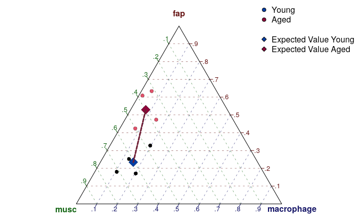

```r
legend("topright", bty = "n", legend = c("Young", "Aged", NA, "Expected Value Young", "Expected Value Aged"),
    pch = c(21, 21, NA, 23, 23), pt.bg = c(div.col[c(1, 100)], NA, div.col[c(1, 100)]))
```

residuals

```r
round(fit5$Y -predict(fit5), 2)
```

```
    fap  musc macrophage
1  0.02  0.01      -0.03
2 -0.05  0.11      -0.05
3  0.09 -0.13       0.04
4 -0.06  0.02       0.04
5 -0.06 -0.02       0.08
6  0.10 -0.08      -0.02
7 -0.11  0.10       0.00
8  0.08 -0.02      -0.06
```